# Midterm-1-Plan

Author

```r
library(tidyverse)
library(palmerpenguins)
```

Show students

```r
str(penguins)
```

```
tibble [344 × 8] (S3: tbl_df/tbl/data.frame)
 $ species          : Factor w/ 3 levels "Adelie","Chinstrap",..: 1 1 1 1 1 1 1 1 1 1 ...
 $ island           : Factor w/ 3 levels "Biscoe","Dream",..: 3 3 3 3 3 3 3 3 3 3 ...
 $ bill_length_mm   : num [1:344] 39.1 39.5 40.3 NA 36.7 39.3 38.9 39.2 34.1 42 ...
 $ bill_depth_mm    : num [1:344] 18.7 17.4 18 NA 19.3 20.6 17.8 19.6 18.1 20.2 ...
 $ flipper_length_mm: int [1:344] 181 186 195 NA 193 190 181 195 193 190 ...
 $ body_mass_g      : int [1:344] 3750 3800 3250 NA 3450 3650 3625 4675 3475 4250 ...
 $ sex              : Factor w/ 2 levels "female","male": 2 1 1 NA 1 2 1 2 NA NA ...
 $ year             : int [1:344] 2007 2007 2007 2007 2007 2007 2007 2007 2007 2007 ...
```

More information about `penguin` df Format A tibble with 344 rows and 8 variables:

- `species`: a factor denoting penguin species (Adélie, Chinstrap and Gentoo)
- `island`: a factor denoting island in Palmer Archipelago, Antarctica (Biscoe, Dream or Torgersen)
- `bill_length_mm`: a number denoting bill length (millimeters)
- `bill_depth_mm`: a number denoting bill depth (millimeters)
- `flipper_length_mm`: an integer denoting flipper length (millimeters)
- `body_mass_g`: an integer denoting body mass (grams)
- `sex`: a factor denoting penguin sex (female, male)
- `year`: an integer denoting the study year (2007, 2008, or 2009)

[output not shown]

Question Idea: Notion: Which of the following is not a data storage type in R? Select all that apply. Format: Multiple Answer

Options: 1. lists 2. vectors 3. data frames 4. containers 5. dictionaries

## Frequency: 1

```r
penguins %>%
  select(species,bill_depth_mm) %>%
  group_by(species) %>%
  summarise(mean = mean(bill_depth_mm, na.rm = TRUE), sd = sd(bill_depth_mm, na.rm = TRUE))
```

```
# A tibble: 3 × 3
  species    mean    sd
  <fct>     <dbl> <dbl>
1 Adelie     18.3 1.22
2 Chinstrap  18.4 1.14
3 Gentoo     15.0 0.981
```

2. [Correct]

```r
penguins %>%
  group_by(species) %>%
  summarise(mean = mean(bill_depth_mm, na.rm = TRUE), sd = sd(bill_depth_mm, na.rm = TRUE))
```

```
# A tibble: 3 × 3
  species    mean    sd
  <fct>     <dbl> <dbl>
1 Adelie     18.3 1.22
2 Chinstrap  18.4 1.14
3 Gentoo     15.0 0.981
```

```r
penguins %>%
  group_by(species) %>%
  mutate(mean = mean(bill_depth_mm), sd = sd(bill_depth_mm))
```

```
# A tibble: 344 × 10
# Groups:   species [3]
   species island    bill_length_mm bill_depth_mm flipper_length_mm body_mass_g
   <fct>   <fct>              <dbl>         <dbl>             <int>       <int>
 1 Adelie  Torgersen           39.1          18.7               181        3750
 2 Adelie  Torgersen           39.5          17.4               186        3800
 3 Adelie  Torgersen           40.3          18                 195        3250
 4 Adelie  Torgersen           NA            NA                  NA          NA
 5 Adelie  Torgersen           36.7          19.3               193        3450
 6 Adelie  Torgersen           39.3          20.6               190        3650
 7 Adelie  Torgersen           38.9          17.8               181        3625
 8 Adelie  Torgersen           39.2          19.6               195        4675
 9 Adelie  Torgersen           34.1          18.1               193        3475
10 Adelie  Torgersen           42            20.2               190        4250
# ℹ 334 more rows
# ℹ 4 more variables: sex <fct>, year <int>, mean <dbl>, sd <dbl>
```

```r
penguins %>%
  select(species,bill_depth_mm) %>%
  group_by(species) %>%
  summarise(mean = mean(bill_length_mm, na.rm = TRUE), sd = sd(bill_length_mm, na.rm = TRUE))
```

```
Error in `summarise()`:
ℹ In argument: `mean = mean(bill_length_mm, na.rm = TRUE)`.
ℹ In group 1: `species = Adelie`.
Caused by error:
! object 'bill_length_mm' not found
```

```r
penguins %>%
  select(species,bill_depth_mm) %>%
  summarise(mean = mean(bill_depth_mm, na.rm = TRUE), sd = sd(bill_depth_mm, na.rm = TRUE)) %>%
  group_by(species)
```

```
Error in `group_by()`:
! Must group by variables found in `.data`.
✖ Column `species` is not found.
```

Version 2: **Which of the following code snippets will find the median, maximum, and minimum of `bill_depth_mm` grouped by `island`? Select all that apply.**

1. [Correct]

```r
penguins %>%
  select(bill_depth_mm,island) %>%
  group_by(island) %>%
  summarise(median = median(bill_depth_mm, na.rm = TRUE), max = max(bill_depth_mm, na.rm = TRUE), min = min(bill_depth_mm, na.rm = TRUE))
```

```
# A tibble: 3 × 4
  island    median   max   min
  <fct>      <dbl> <dbl> <dbl>
1 Biscoe      15.5  21.1  13.1
2 Dream       18.4  21.2  15.5
3 Torgersen   18.4  21.5  15.9
```

2. [Correct]

```r
penguins %>%
  mutate(is_heavy = if_else(body_mass_g >400, "heavy","light")) %>%
  group_by(island) %>%
  summarise(median = median(bill_depth_mm, na.rm = TRUE), max = max(bill_depth_mm, na.rm = TRUE), min = min(bill_depth_mm, na.rm = TRUE))
```

```
# A tibble: 3 × 4
  island    median   max   min
  <fct>      <dbl> <dbl> <dbl>
1 Biscoe      15.5  21.1  13.1
2 Dream       18.4  21.2  15.5
3 Torgersen   18.4  21.5  15.9
```

```r
penguins %>%
  summarise(median = mean(bill_depth_mm, na.rm = TRUE), max = max(bill_depth_mm, na.rm = TRUE), min = min(bill_depth_mm, na.rm = TRUE)) %>%
  group_by(island)
```

```
Error in `group_by()`:
! Must group by variables found in `.data`.
✖ Column `island` is not found.
```

```r
penguins %>%
  group_by(island) %>%
  summarise(median = median(bill_length_mm, na.rm = TRUE), max = sum(bill_length_mm, na.rm = TRUE), min = min(bill_length_mm, na.rm = TRUE))
```

```
# A tibble: 3 × 4
  island    median   max   min
  <fct>      <dbl> <dbl> <dbl>
1 Biscoe      45.8 7558   34.5
2 Dream       44.7 5477.  32.1
3 Torgersen   38.9 1986.  33.5
```

```r
penguins %>%
  group_by(island) %>%
  summarise(median = median(bill_depth_mm), max = max(bill_depth_mm), min = sum(bill_depth_mm))
```

```
# A tibble: 3 × 4
  island    median   max   min
  <fct>      <dbl> <dbl> <dbl>
1 Biscoe      NA    NA     NA
2 Dream       18.4  21.2 2275.
3 Torgersen   NA    NA     NA
```

Format: Multiple Answer Frequency: 2 ——————————————————————–

Notion: What is wrong with this code Format: Multiple Choice or Open-ended Version 1: **What is wrong with the following code?** code:

```r
mod_2_penguins <- penguins %>%
  filter(species == "Adelie")  %>%
  select(bill_depth_mm,island) %>%
  group_by(island) %>%
  summarise(mean = mean(bill_length_mm, na.rm = TRUE))
```

```
Error in `summarise()`:
ℹ In argument: `mean = mean(bill_length_mm, na.rm = TRUE)`.
ℹ In group 1: `island = Biscoe`.
Caused by error:
! object 'bill_length_mm' not found
```

1. The `filter` function is used incorrectly. It should be used to filter rows, not to assign a value to a column.
2. The `select` function is used incorrectly. It should be used to select columns, not to assign a value to a column.
3. The `summarise` function is trying to calculate the mean of `bill_length_mm`, but this column is not available in the data frame after the `select` function is used. [correct]
4. The `group_by` function is used incorrectly. It should be used to group the data frame by a variable, not to assign a value to a column.
5. There is nothing wrong with the code.

Version 2: **What is wrong with the following code?** code:

```r
mod_1_penguins <- penguins %>%
  filter(island %in% c("Torgersen","Dream"))  %>%
  mutate(body_weight_lbs = body_mass_g/453.592) %>%
  only_2008 = year == 2008
```

```
Error in year == 2008: comparison (==) is possible only for atomic and list types
```

1. The `filter` function is used incorrectly. It should be used to filter rows, not to assign a value to a column.
2. The `mutate` function is used incorrectly. It should be used to create or modify columns, not to assign a value to a column.
3. The `only_2008 = year == 2008` operation is outside of the pipeline and is not doing anything. It should be inside a `mutate` function if the intention is to create a new column. [correct]
4. The `filter(island %in% c("Torgersen","Dream"))` operation is incorrect because the `island` column does not exist in the `penguins` data frame.
5. There is nothing wrong with the code.

Version 3: **Explain what is wrong with the following code.** code:

```r
mod_2_penguins <- penguins %>%
  filter(island != "Torgersen")  %>%
  filter(species == "Adelie")  %>%
  select(bill_depth_mm, island, year) %>%
  mutate(is_Torgersen = if_else(island == "Torgersen",True,False) )
```

```
Error in `mutate()`:
ℹ In argument: `is_Torgersen = if_else(island == "Torgersen", True,
  False)`.
Caused by error:
! object 'True' not found
```

Frequency: 2

Show a new function in ggplot and dplyr and ask what it does based on its usage Format: Multiple Choice or Open-ended Frequency: 2

`sample_frac()`: Randomly selects a number of rows or a fraction of rows from the data frame.

Consider the following code snippet:

```r
set.seed(123)
sample_data <- mtcars %>%
  sample_frac(0.5)
```

In this snippet, what does the `sample_frac()` function do?

1. It selects all rows from the `mtcars` data frame.
2. It selects 50% of the rows from the `mtcars` data frame at random. [correct]
3. It selects the first 50% of the rows from the `mtcars` data frame.
4. It selects the last 50% of the rows from the `mtcars` data frame.
5. It selects 50 rows from the `mtcars` data frame at random.

The correct answer is **2**: The `sample_frac()` function randomly selects a fraction of rows from the data frame. In this case, it’s selecting 50% of the rows from the `mtcars` data frame at random. The `set.seed(123)` function is used to set the seed for the random number generator, which ensures that the same set of rows is selected every time the code is run.

`transmute()`: Similar to mutate(), but drops existing variables not explicitly mentioned in the function call.

Consider the following code snippet:

```r
transmuted_data <- mtcars %>%
  transmute(mpg_to_kpl = mpg * 0.425, cyl)
```

In this snippet, what does the `transmute()` function do?

1. It creates a new column `mpg_to_kpl` in the `mtcars` data frame, without dropping any existing columns.
2. It creates a new column `mpg_to_kpl` in the `mtcars` data frame, and drops all other columns not mentioned in the function call. [correct]
3. It modifies the `mpg` column in the `mtcars` data frame to be equal to `mpg * 0.425`.
4. It renames the `mpg` column in the `mtcars` data frame to `mpg_to_kpl`.
5. It creates a new data frame with only the `mpg_to_kpl` and `cyl` columns.

Notion: Understand Variable type is important Format: Multiple Choice or Open-ended

**What is wrong with the following code?**

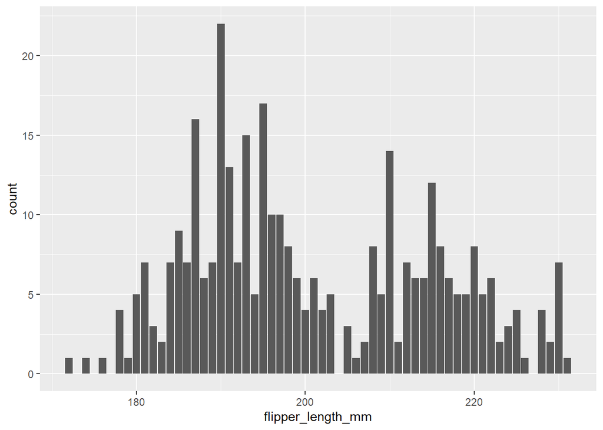

```r
ggplot(penguins, aes(x = flipper_length_mm)) +
  geom_bar()
```

1. `geom_bar()` is used incorrectly. It should be used with a categorical variable, not a quantitative variable like `flipper_length_mm`.
2. The `aes()` function is used incorrectly. It should be used to map variables to aesthetic attributes, not to assign a value to a variable.
3. The `ggplot()` function is used incorrectly. It should be used to create a plot, not to assign a value to a variable.
4. The `flipper_length_mm` variable does not exist in the `penguins` data frame.
5. There is nothing wrong with the code.

**What is wrong with the following code?**

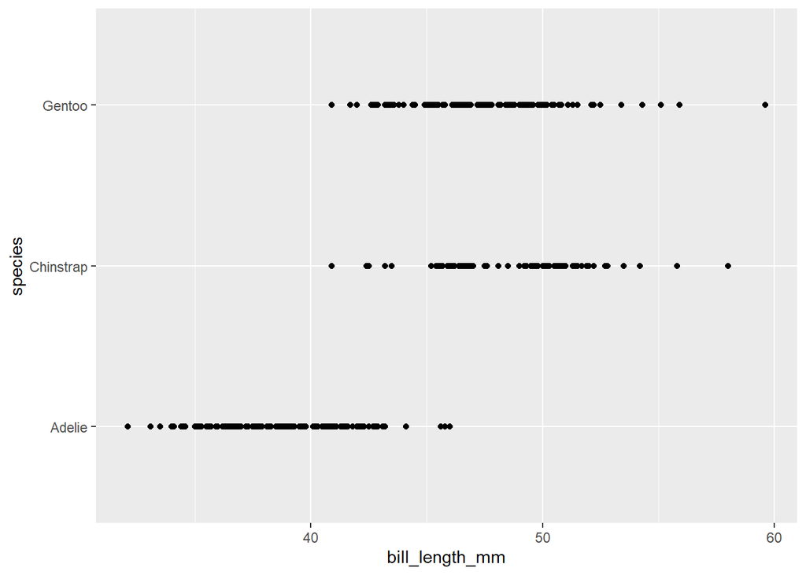

```r
ggplot(penguins, aes(x = bill_length_mm, y = species)) +
  geom_point()
```

1. `geom_point()` is used incorrectly. It should be used with two quantitative variables, not with a categorical variable like `species`.
2. The `aes()` function is used incorrectly. It should be used to map variables to aesthetic attributes, not to assign a value to a variable.
3. The `ggplot()` function is used incorrectly. It should be used to create a plot, not to assign a value to a variable.
4. The `bill_length_mm` or `species` variable does not exist in the `penguins` data frame.
5. There is nothing wrong with the code.

Frequency: 2

Sure, here are five possible options for what could be wrong with each code:

**For the bar plot:** 1. `geom_bar()` is used incorrectly. It should be used with a categorical variable, not a quantitative variable like `flipper_length_mm`. 2. The `aes()` function is used incorrectly. It should be used to map variables to aesthetic attributes, not to assign a value to a variable. 3. The `ggplot()` function is used incorrectly. It should be used to create a plot, not to assign a value to a variable. 4. The `flipper_length_mm` variable does not exist in the `penguins` data frame. 5. There is nothing wrong with the code.

The correct answer is **1**: `geom_bar()` is typically used with a categorical variable, not a quantitative variable like `flipper_length_mm`. If the intention is to create a histogram, `geom_histogram()` should be used instead.